# Sensitivity analysis Oxygen Isotopes in cellulose

##### Mechanistic model of the Oxygen isotopes in cellulose.

##### COURSE: DISC, LTRR, UNIVERSITY OF ARIZONA. INSTRUCTORS: P. SZEJNER & S. BELMECHER

### Instructions:

The following activities with R code and comments should further your experience using tree rings and Oxygen isotopes in cellulose using the R environment. This exercise relies upon multiples estimations to conduct a sensitivity analysis of how different factors affect the oxygen isotopes in the cellulose that we can measure in tree rings. The following calculations, like Notebook 2, will be relying on the use of the Craig Gordon model and the Roden model.

You will need to download or clone the R project from https://github.com/paulszejner/DISCO-Notebook4.git then, each of you will be able to set your working directory to proceed with this exercises. Once you open the `Notebook 4.Rproj` you can open the `Notebook 4.Rmd` file to proceed with the activity.

In this exercise, you will model the oxygen isotopes in cellulose `d18O_cellulose`. However, this exercise is intended for you to evaluate the sensitivity of the different variables. For example, what happens to the cellulose oxygen isotopes if we vary the relative humidity `relH`, the source water `water`, the stomatal conductance`gs` and the percentage of exchange during the cellulose sinthesys`F_0`

## PART 1: Variables to analize its sensitivity

relH <- seq(10, 90, by=5) # this is the vector of 17 different Realtive humidieties water <-seq( -25, 5,by = 2) # this is the vector with all 16 the isotopic values from the water sources.

RH_SOURCE <- merge(relH, water) # here we merge the two variables to facilitate the calculations on each row of this object.

Source_18O <- RH_SOURCE[,2] Relative_humidity <- RH_SOURCE[,1] plot(Relative_humidity, Source_18O)

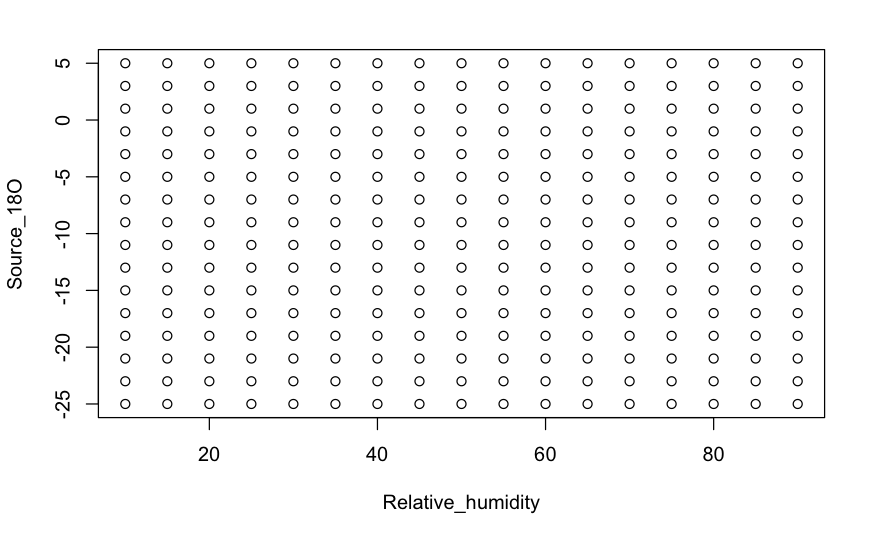

So, we will run the model on all of these options between relative humidity and source water.

## PART 2: Modeling the Oxygen Isotopes in the tree ring cellulose

The following code will guide you step by step through the several isotopic fractionation processes inside the leaf, and during cellulose synthesis. In this occasion, we will run the model using an extensive range of variability on the four critical factors in the model.

water_vapor <- Source_18O +(-1*(1.137*(1000000/((Ta+273.15)^2))-0.4156*((1000/(Ta+273.15))-2.0667))) # where this formula comes from?